# P8131_hw7_rw2844

Renjie Wei

2022-04-07

```r
library(nlme)
```

```r
library(ggplot2)
library(lattice)
library(tidyverse)
library(readr)
pitch <- read_csv("HW7-politeness_data.csv")
```

1. Exploratory analysis: provide boxplots to show the relation between gender/attitude and pitch (ignoring different scenarios).

## Answer

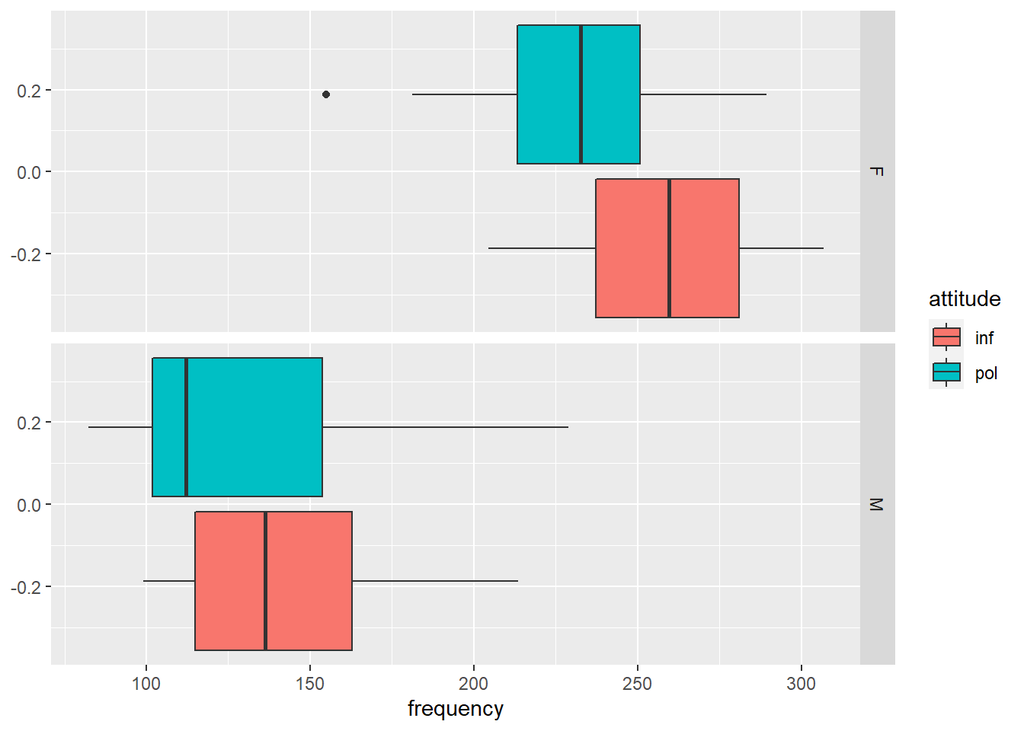

```r
ggplot(pitch, aes(x = frequency, group = attitude, fill = attitude)) + geom_boxplot() + facet_grid("gender")
```

From the boxplot, we can see that:

- Considering gender, the pitch of male is lower than the pitch of female
- Considering attitude, the pitch of polite attitude is lower than the pitch of informal attitude.
- The pitch difference between genders are more obvious than that between different attitudes.
2. Fit a mixed effects model with random intercepts for different subjects (gender and attitude being the fixed effects). What is the covariance matrix for a subject $Y_i$? What is the covariance matrix for the estimates of fixed effects (Hint: 3 ×3 matrix for intercept, gender and attitude)? What are the BLUPs for subject-specific intercepts? What are the residuals?

## Answer

The model is:
$$Y_{ij} = \beta_0 +
\beta_1\times\text{genderM}_{ij} +
\beta_2\times\text{attitudePol}_{ij}+b_i + \epsilon_{ij}$$
where $i = 1,\dots,6, \ j = 1,\dots,n_i$

```r
LMM1 = lme(frequency ~ gender + attitude, random = ~ 1 | subject, data = pitch, method = 'REML')

vcovY1 = VarCorr(LMM1) # covariance estimates for random effects and variance for residuals
SIGMA1 = LMM1$sigma # std for residuals
vcovFE1 = vcov(LMM1) # covariance for fixed effects estimates (inv fisher info)
#
FE1 = fixed.effects(LMM1) # fixed effects coef
RE1 = random.effects(LMM1) # ordered random effects, BLUPs
RES1 = pitch$frequency-fitted(LMM1) # residuals
```

The covariance matrix of $Y_i$ is:
$$\text{cov}(\mathbf{Y}_i) =
\left(\begin{array}{cc}
\sigma_b^2+\sigma^2 & \sigma_b^2&\dots&\sigma_b^2\\
\sigma_b^2&\sigma_b^2+\sigma^2&\dots&\sigma_b^2\\
\dots&&&\dots\\
\sigma_b^2&\sigma_b^2&\dots&\sigma_b^2+\sigma^2
\end{array}\right)
=
\left(\begin{array}{cc}
1445.9 & 598.2&\dots&598.2\\
598.2&1445.9&\dots&598.2\\
\dots&&&\dots\\
598.2&598.2&\dots&1445.9
\end{array}\right)$$

The covariance matrix for the estimates of fixed effects is:
$$\text{cov}(\mathbf{\beta}) =
\left(\begin{array}{cc}
\text{var}(\beta_0) & \text{cov}(\beta_0,\beta_1)&
\text{cov}(\beta_0,\beta_2)\\
\text{cov}(\beta_0,\beta_1) & \text{var}(\beta_1)&
\text{cov}(\beta_1,\beta_2)\\
\text{cov}(\beta_0,\beta_2) & \text{cov}(\beta_1,\beta_2)&
\text{var}(\beta_2)
\end{array}\right)
=
\left(\begin{array}{cc}
229.7 & -219.6&-20.2\\
-219.6&439.16&6.5\times10^{-15}\\
-20.2&6.5\times10^{-15}&40.4
\end{array}\right)$$

The BLUPs for subject-specific intercepts are:

```r
RE1 %>% knitr::kable(caption = "BLUPs for subject-specific intercepts", format = "latex")
```

[output not shown]

3. Fit a mixed effects model with intercepts for different subjects (gender, attitude and their interaction being the fixed effects). Use likelihood ratio test to compare this model with the model in part (b) to determine whether the interaction term is significantly associated with pitch.
4. Write out the mixed effects model with random intercepts for both subjects and scenarios (gender and attitude being the fixed effects). Fit the model using lmer in the lme4 package. Write out the covariance matrix for a subject Yi. What is the interpretation of the coefficient for the fixed effect term attitude?